# 3 Eye-tracking during reading

What can we learn from the measures?

Author

Affiliation

Daniela Palleschi

Humboldt-Universität zu Berlin

Published

July 8, 2023

# 4 Eye-tracking

- in (psycho)linguistics
  - during reading
  - visual world paradigm
- in psychology
  - pupillometry
  - visual search
- but also
  - market research
  - diagnostic tool

## 4.1 Eye movements

- **saccades**: eye *movements* (e.g., from one word to another)
  - average saccade legnth: 7-9 letters (in alphabetic writing systems)
- **fixations**: ‘looking at’ something, e.g., a word (little movement)
  - when information is taken in
  - average duration: 225-250ms (ranging 50-600ms)
- **regressions**: saccades to earlier text
  - occurance: 10-15% of saccades in skilled readers

Rayner (2009)

## 4.2 The eye-tracker

- eye-tracker
  - camera $+$ infrared illuminator
- screen
- chin/head rest
- in our lab: desk-mounted

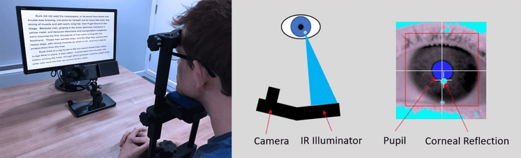

Image source: [SR Research](https://www.sr-research.com/about-eye-tracking/) (all rights reserved)

# 5 Eye-tracking during reading

## 5.1 Eye-tracking reading measures

- inform theories of language processing via linking hypotheses
  - linking visual attention to processing
- typically, we compare reading times as a function of some manipulation
  - e.g., Sally *went*/*goed* to the store.
- longer reading times are taken to reflect processing costs, associated with e.g., sentence complexity or anomalies

## 5.2 Region of interest (ROI)

- can be anything on-screen
  - sentence-level
  - word/region-level
  - a certain part of the screen

[video not shown]

## 5.3 Measures (dependent variables)

- what we measure = *dependent* variables (usually…)
  - their value *depends* on some *predictor* (e.g., word frequency)
- measures of duration (time spent on a region)
  - first fixation
  - first-pass reading time
  - regression path duration
  - total reading time
- data type: *continuous*
- measures of revisits
  - number of fixations
  - number of regressions in/out
  - regression in/out (yes or no)
  - probability of regressions in/out (0:1)
- data type: *binary* (0,1) or *count*

## 5.4 Independent variables

- what can influence reading measures? (Clifton & Staub, 2011; Juhasz & Pollatsek, 2011; Rayner & Liversedge, 2011; Warren, 2011)
  - some examples:
- Word properties
  - word frequency
  - word length
- Sentence-level influences
  - context (i.e., prediction)
  - semantic or grammatical manipulations
- Inter- and intra-individual
  - domain-specific expertise
  - reading skill level

## 5.5 What do these measures tell us?

- eye-tracking during reading can tell use *when* and *where* processing costs are incurred
- *early measures* involve “first contact with a word” or region: first-fixation, first-pass reading time (Vasishth et al., 2013, p. 126)
- *late measures* involve regressions to a region: e.g., total reading time
  - may also include ‘spillover’ effects from early processing
- eye-tracking during reading measures can therefore tell us about stages of processing

# References

Clifton, C., & Staub, A. (2011). Syntactic influences on eye movements during reading. In *Oxford Handbook of Eye Movements*. Oxford University Press. https://doi.org/10.1093/oxfordhb/9780199539789.013.0049

Juhasz, B. J., & Pollatsek, A. (2011). Lexical influences on eye movements in reading. In *Oxford Handbook of Eye Movements*.

Rayner, K. (2009). *Eye movements and attention in reading, scene perception, and visual search* (Vol. 62, Issue 8). https://doi.org/10.1080/17470210902816461

Rayner, K., & Liversedge, S. P. (2011). Linguistic and cognitive influences on eye-movements during reading. In *Oxford Handbook of Eye Movements*.

Vasishth, S., von der Malsburg, T., & Engelmann, F. (2013). What eye movements can tell us about sentence comprehension. *Wiley Interdisciplinary Reviews: Cognitive Science*, *4*(2), 125–134. https://doi.org/10.1002/wcs.1209

Warren, T. (2011). The influence of implausibility and anomaly on eye movements during reading. In *Oxford Handbook of Eye Movements*.